--- title: "Week 10 HW" date: '2025-11-04' author: - name: Polina email: pchubarova@gwu.edu affiliation: - name: George Washington University city: Washington, DC format: html: code-fold: false jupyter: python3 execute: echo: true standalone: true ---

# DATS 2102 – Week 10: Homework

- Select a dataset of your choice (or continue from a previous week).
- Produce the following:
- One scatterplot with regression fit and confidence interval.
- One correlation matrix heatmap.
- One residual plot illustrating model fit or deviation.
- Include a brief interpretation (200–300 words) explaining:
- What relationships did you observe?
- How visualization helped confirm or question your assumptions.
- Submit .ipynb and .html.

### For my data I chose to continue building upon the Penguin Data Set

```python
import pandas as pd
import numpy as np
import seaborn as sns
import matplotlib.pyplot as plt
import statsmodels.api as sm

sns.set_theme()
```

```python
penguins = sns.load_dataset("penguins")
penguins = penguins.dropna()
print(penguins)
```

```
    species     island  bill_length_mm  bill_depth_mm  flipper_length_mm  \
0    Adelie  Torgersen            39.1           18.7              181.0
1    Adelie  Torgersen            39.5           17.4              186.0
2    Adelie  Torgersen            40.3           18.0              195.0
4    Adelie  Torgersen            36.7           19.3              193.0
5    Adelie  Torgersen            39.3           20.6              190.0
..      ...        ...             ...            ...                ...
338  Gentoo     Biscoe            47.2           13.7              214.0
340  Gentoo     Biscoe            46.8           14.3              215.0
341  Gentoo     Biscoe            50.4           15.7              222.0
342  Gentoo     Biscoe            45.2           14.8              212.0
343  Gentoo     Biscoe            49.9           16.1              213.0

     body_mass_g     sex
0         3750.0    Male
1         3800.0  Female
2         3250.0  Female
4         3450.0  Female
5         3650.0    Male
..           ...     ...
338       4925.0  Female
340       4850.0  Female
341       5750.0    Male
342       5200.0  Female
343       5400.0    Male

[333 rows x 7 columns]
```

### One scatterplot with regression fit and confidence interval.

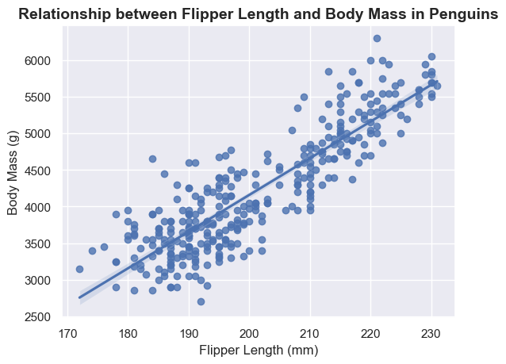

```python
sns.regplot(data=penguins, x="flipper_length_mm", y="body_mass_g")
plt.title("Relationship between Flipper Length and Body Mass in Penguins", fontsize=14, weight='bold')
plt.xlabel("Flipper Length (mm)")
plt.ylabel("Body Mass (g)")
plt.show()
```

### One correlation matrix heatmap.

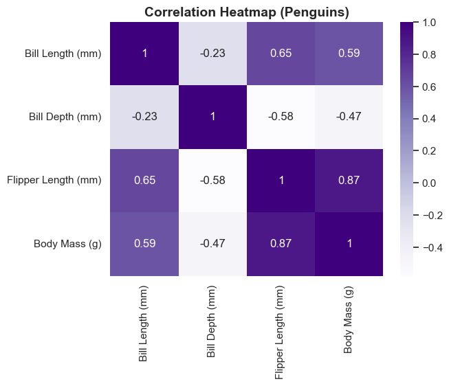

```python
corr = penguins.corr(numeric_only=True)
corr = penguins[['bill_length_mm', 'bill_depth_mm', 'flipper_length_mm', 'body_mass_g']].rename(
    columns={
        'bill_length_mm': 'Bill Length (mm)',
        'bill_depth_mm': 'Bill Depth (mm)',
        'flipper_length_mm': 'Flipper Length (mm)',
        'body_mass_g': 'Body Mass (g)'
    }
).corr()
sns.heatmap(corr, annot=True, cmap="Purples")
plt.title("Correlation Heatmap (Penguins)", fontsize=14, weight='bold')
plt.show()
```